# LCMS with xcms

Pietro Franceschi

12/7/2020

Load the package and the data

```r
library(RColorBrewer) ## nicer color schemes
library(xcms)         ## the package doing the job
library(tidyverse)    ## potentially useful
```

This library is used only to get some raw data to play with …

```r
library(faahKO)
```

we will analyze a subset of the data from in which the metabolic consequences of knocking out the fatty acid amide hydrolase (FAAH) gene in mice was investigated. The raw data files (in NetCDF format) are provided with the faahKO data package. The data set consists of samples from the spinal cords of 6 knock-out and 6 wild-type mice. Each file contains data in centroid mode acquired in positive ion mode form 200-600 m/z and 2500-4500 seconds. To speed up processing of this vignette we will restrict the analysis to only 8 files and to the retention time range from 2500 to 3500 seconds.

**Note** A large parte of this tutorial is taken from the official vignette of [`xcms`](https://bioconductor.org/packages/release/bioc/vignettes/xcms/inst/doc/xcms.html). Many thanks to Steffen Neumann and Juhannes Rainer!

# Part 1

## Data Loading

We start getting some raw data into R.

```r
## Get the full path to the CDF files
cdfs <- dir(system.file("cdf", package = "faahKO"), full.names = TRUE,
            recursive = TRUE)[c(1, 2, 5, 6, 7, 8, 11, 12)]

cdfs
```

```
## [1] "/home/franceschp/R/x86_64-pc-linux-gnu-library/4.0/faahKO/cdf/KO/ko15.CDF"
## [2] "/home/franceschp/R/x86_64-pc-linux-gnu-library/4.0/faahKO/cdf/KO/ko16.CDF"
## [3] "/home/franceschp/R/x86_64-pc-linux-gnu-library/4.0/faahKO/cdf/KO/ko21.CDF"
## [4] "/home/franceschp/R/x86_64-pc-linux-gnu-library/4.0/faahKO/cdf/KO/ko22.CDF"
## [5] "/home/franceschp/R/x86_64-pc-linux-gnu-library/4.0/faahKO/cdf/WT/wt15.CDF"
## [6] "/home/franceschp/R/x86_64-pc-linux-gnu-library/4.0/faahKO/cdf/WT/wt16.CDF"
## [7] "/home/franceschp/R/x86_64-pc-linux-gnu-library/4.0/faahKO/cdf/WT/wt21.CDF"
## [8] "/home/franceschp/R/x86_64-pc-linux-gnu-library/4.0/faahKO/cdf/WT/wt22.CDF"
```

In the last few years the `xcms` developer has been making a big effort to make their package coherent with a general framework for the handling of MS data in R (metabolomics, proteomics, …)

all this goes beyond the scope of our course, for us is sufficient to know that this infrastructure allows to store sample “metadata” (e.g. treatment class, time point, etc) together with the raw experimental data.

In our specific case, the tibble with the phenotypic data could be designed as follow

```r
phenodata <- tibble(sample_name = sub(basename(cdfs), pattern = ".CDF",
                                   replacement = "", fixed = TRUE),
                 sample_group = c(rep("KO", 4), rep("WT", 4)))
phenodata
```

```
## # A tibble: 8 x 2
##   sample_name sample_group
##   <chr>       <chr>
## 1 ko15        KO
## 2 ko16        KO
## 3 ko21        KO
## 4 ko22        KO
## 5 wt15        WT
## 6 wt16        WT
## 7 wt21        WT
## 8 wt22        WT
```

Up to now nothing has been actually loaded into R. To do that

```r
raw_data <- readMSData(files = cdfs,
                       pdata = new("NAnnotatedDataFrame", phenodata), ## this is the structure of xcms holding phenotypic data
                       mode = "onDisk")
```

We next restrict the data set to the retention time range from 2500 to 3500 seconds, just to spare some time …

```r
raw_data <- filterRt(raw_data, c(2500, 3500))
```

## Data Visualization

The raw_data object contains the full set of 2D data collected in all my 8 samples. The “raw” values can be extracted by using

```r
rt <- rtime(raw_data)
mz <- mz(raw_data)
I <- intensity(raw_data)
```

Let’s look to the structure of thse three objects

```r
glimpse(rt)
```

```
##  Named num [1:5112] 2501 2503 2505 2506 2508 ...
##  - attr(*, "names")= chr [1:5112] "F1.S0001" "F1.S0002" "F1.S0003" "F1.S0004" ...
```

These are the retention time in seconds for the chromatography of all the 8 files. “F!.S0001” stands for File1, scan number 1 … it was recorded at 2501 seconde …

Another way to see that

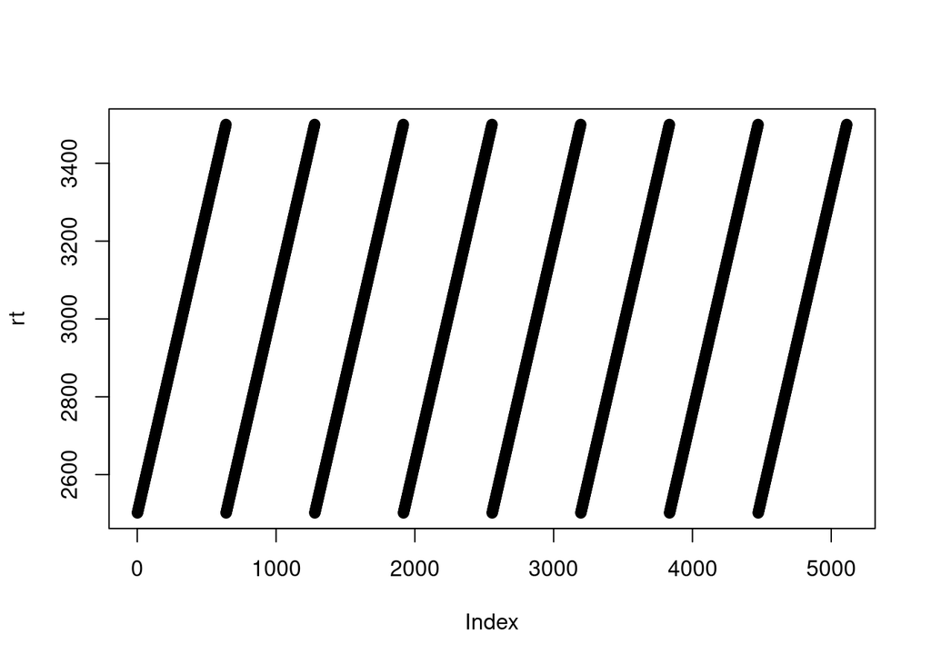

```r
plot(rt)
```

Where we see the increasing time scale for each file.

`mz` and `I` holds the mass spectra collected at each scantime … for this reason the two objects are lists and not vectors. Remember our data are 2d. For each scantime we have a complete mass spectrum

```r
## only the first 20
glimpse(mz[1:20])
```

```
## List of 20
##  $ F1.S0001: num [1:429] 200 201 202 203 204 ...
##  $ F1.S0002: num [1:431] 200 201 202 203 204 ...
##  $ F1.S0003: num [1:431] 200 201 202 203 204 ...
##  $ F1.S0004: num [1:427] 200 201 202 203 204 ...
##  $ F1.S0005: num [1:422] 200 201 202 203 204 ...
##  $ F1.S0006: num [1:433] 200 201 202 203 204 ...
##  $ F1.S0007: num [1:430] 200 201 202 203 204 ...
##  $ F1.S0008: num [1:425] 201 202 203 204 205 ...
##  $ F1.S0009: num [1:434] 201 202 203 204 205 ...
##  $ F1.S0010: num [1:425] 201 202 203 204 205 ...
##  $ F1.S0011: num [1:435] 201 202 203 204 205 ...
##  $ F1.S0012: num [1:431] 201 202 203 204 205 ...
##  $ F1.S0013: num [1:438] 201 202 203 204 205 ...
##  $ F1.S0014: num [1:445] 201 202 203 204 205 ...
##  $ F1.S0015: num [1:429] 201 202 203 204 205 ...
##  $ F1.S0016: num [1:427] 201 202 203 204 205 ...
##  $ F1.S0017: num [1:428] 201 202 203 204 205 ...
##  $ F1.S0018: num [1:431] 201 202 203 204 205 ...
##  $ F1.S0019: num [1:435] 201 202 203 204 205 ...
##  $ F1.S0020: num [1:425] 201 202 203 204 205 ...
```

```r
## only the first 20
glimpse(I[1:20])
```

```
## List of 20
##  $ F1.S0001: num [1:429] 1716 1723 2814 1961 667 ...
##  $ F1.S0002: num [1:431] 1502 1930 2893 1753 699 ...
##  $ F1.S0003: num [1:431] 1453 1828 3145 1521 728 ...
##  $ F1.S0004: num [1:427] 1650 1655 3499 1414 656 ...
##  $ F1.S0005: num [1:422] 1807 1589 3686 1285 590 ...
##  $ F1.S0006: num [1:433] 1698 1732 3778 1219 626 ...
##  $ F1.S0007: num [1:430] 1486 2089 3938 1236 893 ...
##  $ F1.S0008: num [1:425] 2280 4256 1333 1135 1628 ...
##  $ F1.S0009: num [1:434] 2374 4358 1318 1226 1560 ...
##  $ F1.S0010: num [1:425] 2539 4160 1226 1131 1453 ...
##  $ F1.S0011: num [1:435] 3043 3844 1144 1002 1466 ...
##  $ F1.S0012: num [1:431] 3730 3943 1211 858 1432 ...
##  $ F1.S0013: num [1:438] 4521 4384 1318 779 1281 ...
##  $ F1.S0014: num [1:445] 5422 4793 1439 733 1249 ...
##  $ F1.S0015: num [1:429] 6319 4884 1534 782 1219 ...
##  $ F1.S0016: num [1:427] 7074 4872 1677 871 1171 ...
##  $ F1.S0017: num [1:428] 7600 4702 1624 985 1157 ...
##  $ F1.S0018: num [1:431] 7726 4443 1476 1013 1150 ...
##  $ F1.S0019: num [1:435] 7646 4142 1381 936 1144 ...
##  $ F1.S0020: num [1:425] 7512 3877 1308 804 1196 ...
```

We can plot a complete spectrum (here the first scan of the first sample …)

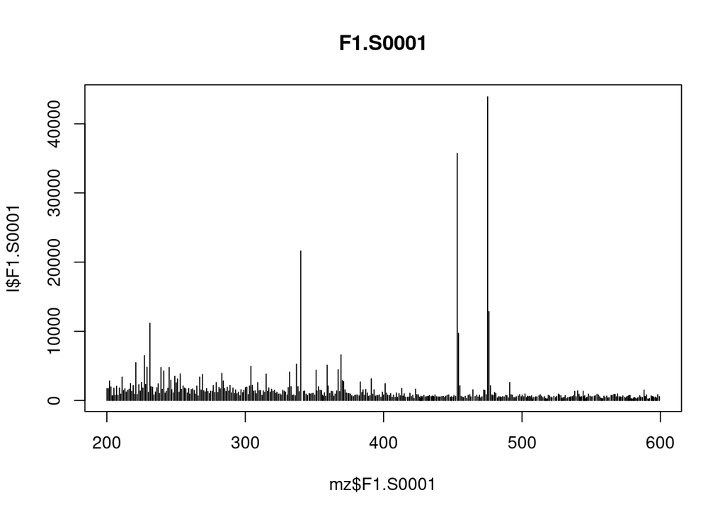

```r
plot(mz$F1.S0001,I$F1.S0001, type = "h", main = names(mz)[1])
```

Ok, working with all files together is not the best … for visualization and handling. To facilitate the “cutting” by file, xcms is provided with a `split()` function which can be combined with a `fromFile` function to create a list with the content separate by file

```r
by_file_mz <- split(mz, fromFile(raw_data))
by_file_rt <- split(rt, fromFile(raw_data))
by_file_I <- split(I, fromFile(raw_data))
length(by_file_mz)
```

```
## [1] 8
```

As we discussed, metabolites are visible as peaks ia 2d mz/rt plane …

```r
mytibble <- tibble(rt = by_file_rt[[2]], mz = by_file_mz[[2]], I = by_file_I[[2]])
mytibble
```

```
## # A tibble: 639 x 3
##       rt mz           I
##    <dbl> <named list> <named list>
##  1 2501. <dbl [424]>  <dbl [424]>
##  2 2503. <dbl [423]>  <dbl [423]>
##  3 2505. <dbl [433]>  <dbl [433]>
##  4 2506. <dbl [427]>  <dbl [427]>
##  5 2508. <dbl [423]>  <dbl [423]>
##  6 2509. <dbl [427]>  <dbl [427]>
##  7 2511. <dbl [427]>  <dbl [427]>
##  8 2512. <dbl [431]>  <dbl [431]>
##  9 2514. <dbl [425]>  <dbl [425]>
## 10 2515. <dbl [427]>  <dbl [427]>
## # … with 629 more rows
```

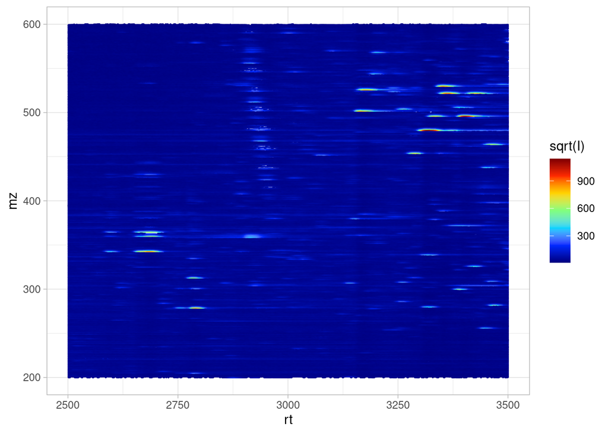

```r
jet.colors <- colorRampPalette(c("#00007F", "blue", "#007FFF", "cyan", "#7FFF7F", "yellow", "#FF7F00", "red", "#7F0000"))

mytibble %>%
  unnest(c("mz","I")) %>%
  ggplot() +
  geom_point(aes(x = rt, y = mz, col = sqrt(I)), size = 0.1) +
  scale_color_gradientn(colours = jet.colors(7)) +
  theme_light()
```

1. A mass spectrum can be seen as a vertical cut of the previous map …
2. Some of the “peaks” are organized in vertical groups … these are the ions coming from the same metabolite …

In the first phase of the inspection is useful to visualize the “total” chromatograpic current …

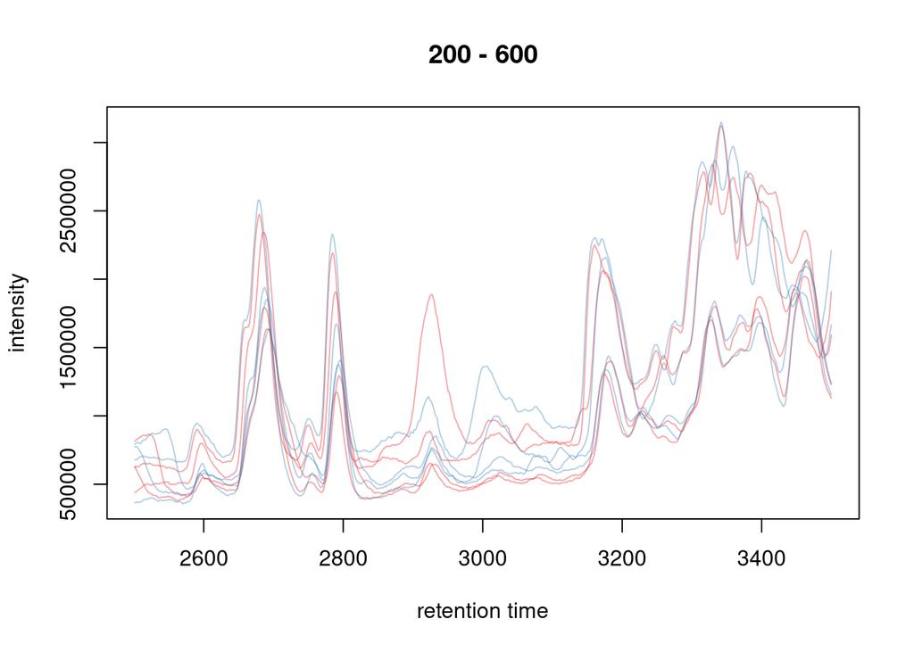

```r
## Get the total ion chromatograms. This reads data from the files.
tics<- chromatogram(raw_data, aggregationFun = "sum")
## Define colors for the two groups
group_colors <- paste0(brewer.pal(3, "Set1")[1:2], "60")
names(group_colors) <- c("KO", "WT")

## Plot all chromatograms.
plot(tics, col = group_colors[raw_data$sample_group])
```

```r
## raw_data$sample_group extracts the info on the phenotipic data inside the raw_data
```

This visualization already shows you how it will be tricky to “match” the differnt samples. Some of the peaks are present everywhere, but others show-up only in specific samples …

# Part 2